# Seminar 10: Digitisation

LSE ME314: Introduction to Data Science and Machine Learning

Modified

July 28, 2026

## Plan for today:

- Digital data: bits, bytes, and Base64
- Character encoding: how text is stored as bytes, and fixing encoding issues
- Importing, manipulating, and using image data
- Using geospatial data for computation and visualization
- Bonus: working with audio data

## Setup

```r
# load packages
package_check <- function(need = c()) {
  have <- need %in% rownames(installed.packages()) # checks packages you have
  if (any(!have)) {
    install.packages(need[!have])
  } # install missing packages
  invisible(lapply(need, library, character.only = TRUE))
}

# remotes::install_github("ropensci/parzer", upgrade = FALSE) # for parsing coordinates

required_packages <- c(
  "readr", # for reading text files and handling encoding
  "openssl", # for Base64 encoding of binary data
  "dplyr", # for data management
  "ggplot2", # for plotting
  "tibble", # for data frames
  "tidyr", # for data tidying
  "jpeg", # for working with image data
  "caret", # for machine learning
  "randomForest", # For random forests
  "sf", # for geospatial data (beautiful package)
  "leaflet", # for interactive maps
  "parzer" # for parsing coordinates
)

package_check(required_packages)

set.seed(12345)
```

### Directory management and setup

Before we proceed, let’s do some “directory management”. For this seminar code to run, it is really important that you set up your directories correctly. You only need to set your working directory to the folder called `seminar10` on your computer (the git repo you cloned for today’s seminar).

```r
# the data directories, relative to the seminar folder
setwd("/Users/charlottekuberka/Desktop/ME314/2026_versions/Seminar10")

ddir <- "data"
mdir <- "data/mps"

required_data <- c(
  "London_Boroughs",
  "mps",
  "pubs_coords.csv",
  "utf-examples-8.txt",
  "utf-examples-16.txt",
  "utf-examples-32.txt"
)
if (all(required_data %in% list.files(ddir))) {
  cat("Data directory correctly set up\n")
} else {
  cat(
    "You have misspecified the directory. Please read the instructions above carefully and try again.\n"
  )
}
```

## Exercise 1: Digital data and bytes

Everything on a computer is stored as **bits** (0s and 1s), grouped into **bytes** (8 bits). Before we worry about what data *means*, let’s look at how R stores it as raw bytes, and how we can move non-text data through text-only channels using Base64.

When you create an object in R, you are making digital data. R shows it to you in a friendly format (R interprets it for us already and provides the data in a readable format ), but you can ask for the underlying bytes.

```r
x <- 5L # an integer object
as.raw(x) # the byte, written as a hex code (minimal R interpretation)
as.integer(x) # the same byte in decimal
```

We can also see the raw bits. The line below writes out the eight bits of the byte:

```r
paste(rev(as.integer(rawToBits(as.raw(x)))), collapse = "")
```

Now it’s your turn. In the chunk below, show the integer `20` as a hex code, as a decimal, and as binary bits.

```r
# Your code goes here
```

Every file on your computer is just bytes. When you read a file normally, R “translates” those bytes into objects you recognise. But you can also read the raw bytes with no translation:

```r
raw_bytes <- read_file_raw(paste0(ddir, "/pubs_coords.csv"))
head(raw_bytes) # the first six bytes (not rows!)
```

Because a `.csv` is really just text, we can translate those bytes back into characters:

```r
rawToChar(head(raw_bytes, 40)) # the first 40 bytes, read as text
```

A file should contain exactly as many bytes as its size on disk. In the chunk below, use `length()` to count the bytes in `raw_bytes`, and compare this to the file’s size in your computer’s file browser.

```r
# Your code goes here
```

Character encoding (the next exercise) only works for text. Lots of data is **binary**: an image or audio file is not text, so reading its bytes as characters gives gibberish. Sometimes we still need to move binary data through a **text-only** channel (an email, a JSON field, a web request). **Base64** solves this by re-encoding binary bytes as safe text.

Let’s read the raw bytes of one of the MP photos (a JPEG):

```r
jpg_file <- list.files(mdir, pattern = "\\.jpg$", full.names = TRUE)[1]
jpg_bytes <- read_file_raw(jpg_file)
head(jpg_bytes, 15) # not text! these are the raw JPEG bytes
```

Now we Base64-encode the first 30 bytes. Base64 represents every 6 bits with one character, so it needs $2^6 = 64$ different characters:

```r
library("openssl")
encoded <- base64_encode(jpg_bytes[1:30])
encoded
```

Base64 has a cost: each character encodes 6 bits but takes 8 bits (one byte) to store, so Base64 text is about 33% larger than the original. In the chunk below, confirm this by comparing the number of characters in `encoded` to the 30 raw bytes, and decode it back with `base64_decode()` to check that it round-trips.

```r
# Your code goes here
```

## Exercise 2: Encoding

In this exercise we will discuss character encoding: how text is stored as bytes, and why encoding issues arise.

**Encoding Basics:**

*To encode means to use something to represent something else. An encoding is the set of rules with which to convert something from one representation to another.*

- Computers do not store letters, books or pictures $\rightarrow$ they store bits
- Bits are the smallest unit of storage on a computer: a 0 or 1
- **Encoding** = the mapping between character and code points
- Encodings use differing number of bits to represent characters: 7-bit, 8-bit, 16-bit, etc.

**Bits:**

- 8 bits are 1 byte
- With n bits, we can store $2^n$ patterns
- Bits represent letters and other characters using a combination of 0 and 1 based on some regulation $\rightarrow$ ASCII
- Bits are *case-sensitive*
- Kilobytes, megabytes, gigabytes, etc. are metric aggregations of bytes

**ASCII and Unicode:**

- ASCII is the original character set/ encoding, only used 7 bits and was then extended to 8 (ISO-8859-1) $\rightarrow$ $2^8$ = 256 characters
- **Unicode** = a universal character set, stored using encodings such as UTF-8 (the most common), UTF-16, or UTF-32

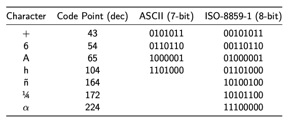

**Mojibake** = underlying bit sequences translated into the wrong characters $\rightarrow$ wrongly detected encoding of a text file returns gibberish

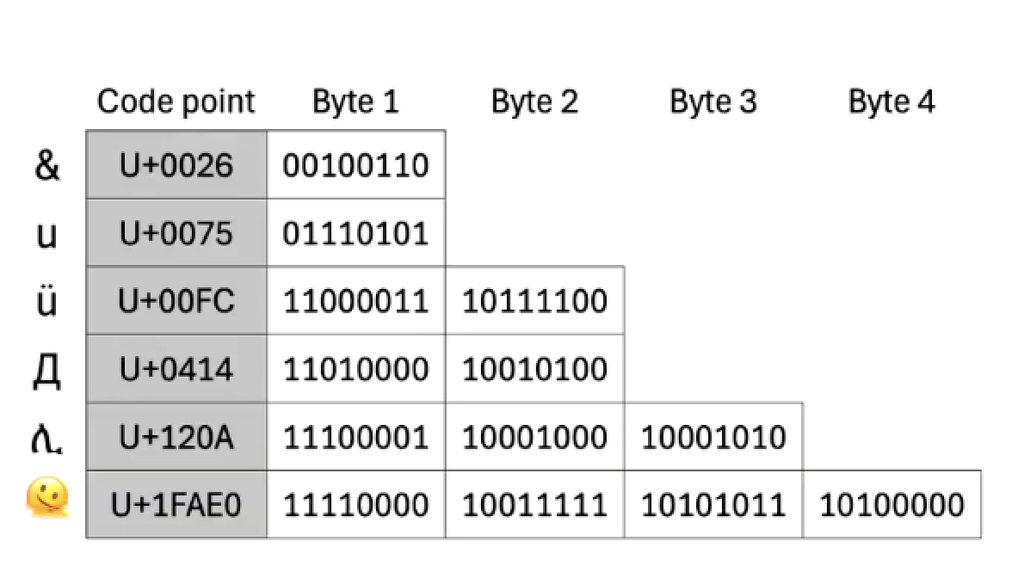

First, let’s examine how special characters can affect file size. Since `readr` encodes all text files with UTF-8, special characters will require more bytes.

When a plain text file is initially saved, it has an encoding. But the encoding is not stored as metadata in plain text files.

By default `readr` will encode files it saves as UTF-8. As far as we know, you cannot choose a different encoding when you write a file in `readr` using `write_file`. For the most part, this is not only okay, it’s preferable. Let’s see why through some examples.

We created three files in which we wrote “&uüДሊ🫠” using different encodings:

- `utf-examples-8.txt` (UTF-8): 13 bytes
- `utf-examples-16.txt` (UTF-16): 16 bytes
- `utf-examples-32.txt` (UTF-32): 28 bytes

Note that the UTF-32 encoded file is more than double the size of UTF-8 (just to store the same characters!). Next, let’s try to open them.

```r
read_file("data/utf-examples-8.txt") # This works (sort of...)
```

```r
read_file("data/utf-examples-16.txt") # This drops most of the characters
```

```r
read_file("data/utf-examples-32.txt") # This drops most of the characters
```

**Questions**:

- Why do so many characters disappear or get corrupted when using UTF-16 or UTF-32, compared to UTF-8? What causes this?

**In case of encoding issues:**

```r
# For a character vector x, obtain texts assuming a different encoding with
parse_character(x, locale = locale(encoding = "Latin1"))

# or to make a guess about encoding in R
guess_encoding(charToRaw(x))
```